# A Hotel Cancellation Prediction Tool

Team #64 - Patil Rutuja, Liu Yuxin, Hui Fei, van Keulen Alessio

April 24, 2022

# 1 Introduction

With the advent and outreach of cellular web-technologies including ecommerce marketplaces, hotel booking platforms, and travel websites, the hospitality industry has seen major revolutions in terms of market exposure and capitalization. In the last decade, this revolution is especially noticeable in the lodging sector, where existing hotels, bed & breakfasts, inns, and other similar business have been witnessing an expanding portfolio of alternative and more affordable solutions for travelers in seek for a temporary accommodation. Other than the inherent increase in the competition, hotel managers and concierge, must deal with a more concrete problem: increasing reservation cancellation patterns.

# 2 Overview

This study will attempt at describing and understanding the underlying forces that drive reservation cancellation decisions by customers toward their original lodging choices. Leveraging data analytics tools and practices, this analysis will distillate those factors that accompany a customer throughout their travel experience, into an essential set of variables that will accurately predict future reservation and cancellation patterns with similar characteristics. Finally, based on these observations, the project will serve as an effective prescription tool for optimizing vacancy and profits.

# 3 Data Preprocessing

Data preprocessing in crucial step in our study. It will help enhance the quality of data to promote the extraction of meaningful insights. This technique involves preparing (cleaning and organizing) the raw data to make it suitable for a building and training Machine Learning models.

## 3.1 Data Import & Preliminary Manipulation

Let’s take a look at the structure as it is imported in R

```r
  # Clear working environment
  rm(list = ls())

  # Data Import
  data_raw <- read.csv(unz("__raw_hotel_data.zip","raw_hotel_data.csv"), header = T, stringsAsFactors = TRUE)

  # Quick Glance at the Data Structure
  str(data_raw)
```

```
'data.frame':   119390 obs. of  33 variables:
 $ hotel                         : Factor w/ 2 levels "City Hotel","Resort Hotel": 2 2 2 2 2 2 2 2 2 2 ...
 $ is_canceled                   : int  0 0 0 0 0 0 0 0 1 1 ...
 $ lead_time                     : int  342 737 7 13 14 14 0 9 85 75 ...
 $ arrival_date_year             : int  2015 2015 2015 2015 2015 2015 2015 2015 2015 2015 ...
 $ arrival_date_month            : Factor w/ 12 levels "April","August",..: 6 6 6 6 6 6 6 6 6 6 ...
 $ arrival_date_week_number      : int  27 27 27 27 27 27 27 27 27 27 ...
 $ arrival_date_day_of_month     : int  1 1 1 1 1 1 1 1 1 1 ...
 $ stays_in_weekend_nights       : int  0 0 0 0 0 0 0 0 0 0 ...
 $ stays_in_week_nights          : int  0 0 1 1 2 2 2 2 3 3 ...
 $ adults                        : int  2 2 1 1 2 2 2 2 2 2 ...
 $ children                      : int  0 0 0 0 0 0 0 0 0 0 ...
 $ babies                        : int  0 0 0 0 0 0 0 0 0 0 ...
 $ meal                          : Factor w/ 5 levels "BB","FB","HB",..: 1 1 1 1 1 1 1 2 1 3 ...
 $ country                       : Factor w/ 178 levels "ABW","AGO","AIA",..: 137 137 60 60 60 60 137 137 137 137 ...
```

[output cut: 19 more lines]

> 🔍 **OBSERVATIONS:** It looks like some variable are imported with the wrong data type:
> - **is_canceled**, our response variable, is imported as INT but can only assume two values. We will convert this to FACTOR
> - **arrival_date_month** is imported as Factor. We will change the months to its numerical representation, and switch the type to INT
> - **arrival_date_week_number**, will be dropped as irrelevant since we have all other date related information already
> - **is_repeated_guest**, is imported as INT but can only assume two values. We will convert this to FACTOR
> - **reservation_status_date** is imported as factor. We will change this to the data type DATE

```r
  data <- data_raw

  # Preliminary data manipulation
  data <- data %>%
    mutate(is_canceled = as.factor(is_canceled)) %>%
    mutate(arrival_date_month = as.integer(match(arrival_date_month, month.name))) %>%
    mutate(is_repeated_guest = as.factor(is_repeated_guest)) %>%
    mutate(reservation_status_date = as.Date(reservation_status_date, format = "%m/%d/%Y")) %>%
    dplyr::select(-arrival_date_week_number)
```

## 3.2 Distribution Analysis

This step involves the visualization of the distribution for each variable in our data set. This is a good technique to get an immediate understanding of how data flows through the sample period (2015-2017), and it could hint at trends and possible cyclical patterns.

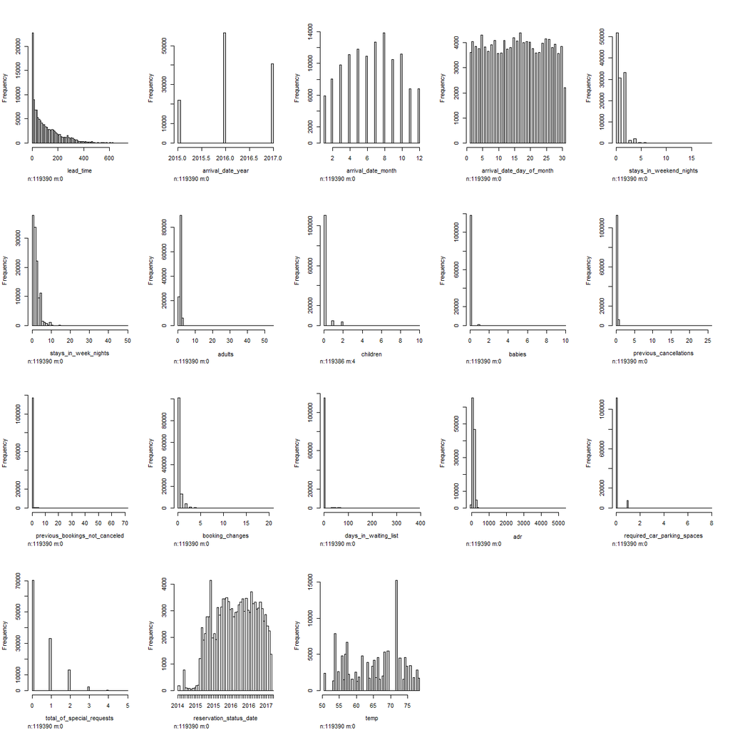

```r
  hist(data[ , -which(names(data) %in% c( "hotel","is_canceled","meal","country","continent","market_segment", "distribution_channel","reserved_room_type","assigned_room_type",
               "deposit_type","agent","company", "customer_type","reservation_status","is_repeated_guest"))])
```

> 🔍 **OBSERVATIONS:**
> - For each plot the variable’s range is drawn on the X axis, and the frequency of occurrence on the Y axis
> - It stands out immediately how almost every variable is right skewed (positively skewed)
> - This suggests a pattern probably indicative of naturally expected preference in hotel reservation behavior (e.g., popular dates are in during summer time).

Now let’s look at the categorical (factor) variables.

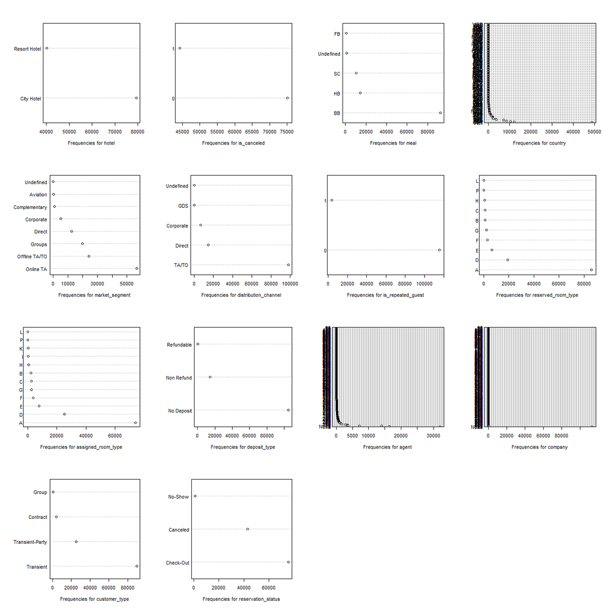

```r
  hist(data[, which(names(data) %in% c( "hotel","is_canceled","meal","country","continent","market_segment", "distribution_channel","reserved_room_type","assigned_room_type",
               "deposit_type","agent","company", "customer_type","reservation_status","is_repeated_guest"))])
```

## 3.3 Outlier Analysis (Univariate)

The first step in the data preprocessing phase involves scanning for outliers. This may help us remove observations that can potentially skew or bias the results in our study. The easiest way to detect outliers if by using visualization techniques. Note that outlier detection requires a qualitative approach before deciding whether or not the data set needs to be discarded. Univariate Outlier Analysis involves addressing one variable at a time, free from any relationship they may have with other variables. These relationship would become apparent only after a statistical model is built, and for this reason this outlier analysis step is considered At Priori: before the actual study takes place. Any outlier that emerges after a regression analysis is considered At Posteriori, and will be covered later.

### 3.3.1 Outlier Visualization

> ⚠️ **NOTE:** Some other approaches suggest to check for missing values first. We have decided to check for outlier as a first step, because we believe that eventual data imputation for missing values, using **Mode, Mean, Median** techniques may be negatively influenced by outliers.

Because we don’t know how variables may be related toward one another, we will be a bit more lenient with defining what constitutes an outlier. We will start with some visual aids:

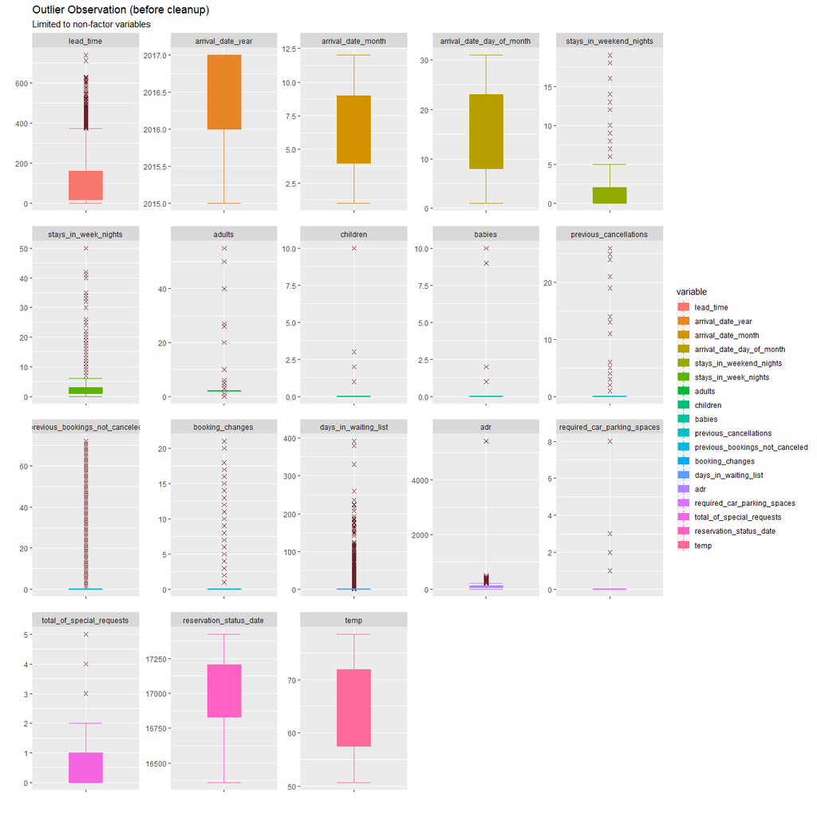

```r
  # The best way to have a quick glance at the distribution and eventual outliers is by using visual tools.
  ggplot(melt(data), aes(variable, value, color=variable, fill=variable)) +
    stat_boxplot(geom ='errorbar') +
    geom_boxplot(outlier.color = "#721c24", outlier.size = 2, outlier.shape = 4, ) +
    facet_wrap(~variable, scale="free") +
    scale_x_discrete(expand = c(0.6,0.6), label = "") +
    labs(title = "Outlier Observation (before cleanup)", subtitle = "Limited to non-factor variables", x = "", y = "")
```

> 🔍 **OBSERVATIONS:** At a first glance, it looks like many of these variables have observations that are found outside the whiskers for each boxplot. This would suggest that the data point is an outlier. However, a more qualitative approach needs to be respected when interpreting outliers. In the next step we will address outliers using a combination of the **Percentile** method and some educated guessing based on the underlying significance of each variable.

### 3.3.2 Outlier Detection

Although visual tools are very helpful to get a panoramic view of the variable, to accurately detect outliers we need to have a better understand of the variable’s distribution. In particular, we will adopt the percentile method. This involves defining a lower and upper boundaries within which the majority of the observations is to be found. Anything beyond these boundaries is a potential outlier.

> ⚠️ **NOTE:** This method only really works for variables that have a very large range. Take a look at the ranges for each variable in the plots above. For the variables **adults**, **children**, **babies** it looks like the majority of the distribution is concentrated in the colored box (usually 2 adults, 0 children, and 0 babies). But since the vast majority of observations is packed in such a small range, many data points seem to fall outside the acceptable boundaries.  
> However, albeit dreadful, families may have 2 or more children/babies travelling with them (…that would not be a vacation anymore, but a nightmare, I give you that 😱!)

We will define two pair of boundaries: a common one, and a more strict one that will define our percentiles. Then we will count how many outliers are found. Because of the assumption that Univariate Outlier detection may lead to false positives, we will probably lean toward using the stricter percetiles. Any result that still seem to be indicative of a wrong outlier detection, will be addresses qualitatively.

We will not consider these variables:

- *arrival_date_week_number* as it presents no data points outside the whiskers, and the distribution is somewhat uniform
- *arrival_date_day_of_month* as it presents no data points outside the whiskers, and the distribution is somewhat uniform
- *ex_rate* since this data point was added, we know that it applies to the foreign customers, which is a smaller group in the distribution
- *temp* as it presents no data points outside the whiskers, and the distribution is somewhat uniform

```r
  # Let's define two standard lower and upper thresholds
  # The overwhelming majority of the observations should fall within this range
  l_thresh = 0.025
  h_thresh = 0.975

  ll_thresh = 0.01
  hh_thresh = 0.99

  # Total observations
  n = nrow(data)

  # Omit Certain Columns
  data_copy = data[ , -which(names(data) %in% c("arrival_date_year", "arrival_date_month", "arrival_date_week_number","arrival_date_day_of_month","ex_rate","temp"))]

  # Let's store our discoveries in a nice formatted table
  d <- data.frame(matrix(ncol=5,nrow=0, dimnames=list(NULL, c("Column", "Range1", "n_outliers1", "Range2", "n_outliers2"))))

  # Loop through all non-categorical variables in our data
  for(i in 1:length(data_copy)){

    # Do this only for numerical and integer data types
    if(class(data_copy[[i]])  ==  "integer" || class(data_copy[[i]])  ==  "numeric"){

      colname = colnames(data_copy[i])
      low_per = quantile(data_copy[i], l_thresh, na.rm = TRUE)
      high_per = quantile(data_copy[i], h_thresh, na.rm = TRUE)
      lower_per = quantile(data_copy[i], ll_thresh, na.rm = TRUE)
      higher_per = quantile(data_copy[i], hh_thresh, na.rm = TRUE)

      howmany1 = length(which(data_copy[i] < low_per | data_copy[i] > high_per))
      howmany2 = length(which(data_copy[i] < lower_per | data_copy[i] > higher_per))

      d[nrow(d) + 1, ] = c(
        colname,
        paste(low_per, "-", high_per),
        percent(howmany1 / n, accuracy = 0.01),
        paste(lower_per, "-", higher_per),
        percent(howmany2 / n, accuracy = 0.01))
    }
  }

  knitr::kable(d, col.names = c(
    "Variable",
    "Range of Values within percentiles 2.5%-97.5%",
    "% of Outliers Detected",
    "Range of Values within percentiles 1%-99%",
    "% of Outliers Detected"))
```

| Variable | Range of Values within percentiles 2.5%-97.5% | % of Outliers Detected | Range of Values within percentiles 1%-99% | % of Outliers Detected |
| --- | --- | --- | --- | --- |
| lead_time | 0 - 374 | 2.50% | 0 - 444 | 0.99% |
| stays_in_weekend_nights | 0 - 3 | 1.84% | 0 - 4 | 0.29% |
| stays_in_week_nights | 0 - 7 | 1.95% | 0 - 10 | 0.34% |
| adults | 1 - 3 | 0.40% | 1 - 3 | 0.40% |
| children | 0 - 2 | 0.06% | 0 - 2 | 0.06% |
| babies | 0 - 0 | 0.77% | 0 - 0 | 0.77% |
| previous_cancellations | 0 - 1 | 0.36% | 0 - 1 | 0.36% |
| previous_bookings_not_canceled | 0 - 1 | 1.74% | 0 - 3 | 0.98% |
| booking_changes | 0 - 2 | 1.32% | 0 - 3 | 0.54% |
| days_in_waiting_list | 0 - 31 | 2.50% | 0 - 75 | 0.99% |
| adr | 29 - 221.38275 | 4.94% | 0 - 252 | 0.98% |
| required_car_parking_spaces | 0 - 1 | 0.03% | 0 - 1 | 0.03% |
| total_of_special_requests | 0 - 2 | 2.41% | 0 - 3 | 0.32% |

> 🔍 **OBSERVATIONS:**
> - The percentile method alone is not suitable for most of the variables, as their range is too small
> - The **adr** column seems to present a large amount of outliers, so percentiles will be manually adjusted
> - The **ex_rate** describes the currency cost of exchange for international travelers, we won’t consider this variable

> Finally, although some values seem to be wildly off the general mean in the distribution, the observation may still make sense in relationship with other variables. For example, if **required_car_parking_spaces** presents a value of “10”, that could make sense if the **customer_type** was: “Transient-Party”. However, these type of observations are not conclusive for the purpose of our study, and may drive our interpretations and conclusions down the wrong path, for this reason we have decided to discard them.

```r
  # Finally cleanup all the found outliers
  lower_bound = quantile(data$lead_time, ll_thresh)
  upper_bound = quantile(data$lead_time, hh_thresh)
  outlier_inds <- which(data$lead_time < lower_bound | data$lead_time > upper_bound)

  lower_bound = quantile(data$stays_in_weekend_nights, ll_thresh)
  upper_bound = quantile(data$stays_in_weekend_nights, hh_thresh)
  outlier_inds <- append(outlier_inds, which(data$stays_in_weekend_nights < lower_bound | data$stays_in_weekend_nights > upper_bound))

  lower_bound = quantile(data$stays_in_week_nights, ll_thresh)
  upper_bound = quantile(data$stays_in_week_nights, hh_thresh)
  outlier_inds <- append(outlier_inds, which(data$stays_in_week_nights < lower_bound | data$stays_in_week_nights > upper_bound))

  lower_bound = quantile(data$stays_in_week_nights, ll_thresh)
  upper_bound = quantile(data$stays_in_week_nights, hh_thresh)
  outlier_inds <- append(outlier_inds, which(data$stays_in_week_nights < lower_bound | data$stays_in_week_nights > upper_bound))

  outlier_inds <- append(outlier_inds, which(data$adults < 1 | data$adults > 4))
  outlier_inds <- append(outlier_inds, which(data$children < 0 | data$children > 4))
  outlier_inds <- append(outlier_inds, which(data$babies < 0 | data$babies > 4))
  outlier_inds <- append(outlier_inds, which(data$previous_cancellations < 0 | data$previous_cancellations > 9))
  outlier_inds <- append(outlier_inds, which(data$previous_bookings_not_canceled < 0 | data$previous_bookings_not_canceled > 9))

  lower_bound = quantile(data$booking_changes, ll_thresh)
  upper_bound = quantile(data$booking_changes, hh_thresh)
  outlier_inds <- append(outlier_inds, which(data$booking_changes < lower_bound | data$booking_changes > upper_bound))

  outlier_inds <- append(outlier_inds, which(data$days_in_waiting_list < 0 | data$days_in_waiting_list > 100))
  outlier_inds <- append(outlier_inds, which(data$adr < 1 | data$adr > 1000))

  lower_bound = quantile(data$required_car_parking_spaces, ll_thresh)
  upper_bound = quantile(data$required_car_parking_spaces, hh_thresh)
  outlier_inds <- append(outlier_inds, which(data$required_car_parking_spaces < lower_bound | data$required_car_parking_spaces > upper_bound))

  outlier_inds <- append(outlier_inds, which(data$total_of_special_requests < 0 | data$total_of_special_requests > 2))

  outlier_inds <- unique(outlier_inds)

  data <- data[-c(outlier_inds), ]
```

Let’s take a look at an updated visual representation of the outliers.

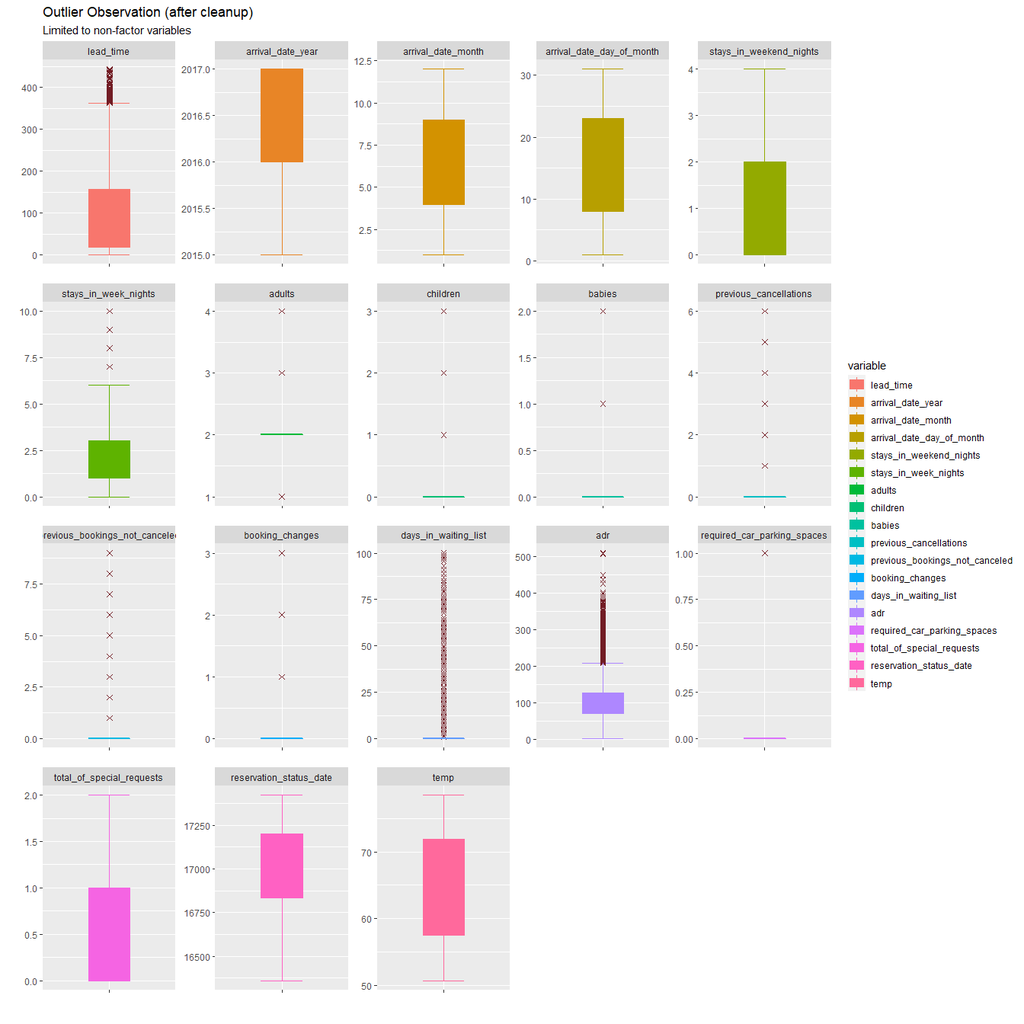

```r
  ggplot(melt(data), aes(variable, value, color=variable, fill=variable)) +
    stat_boxplot(geom ='errorbar') +
    geom_boxplot(outlier.color = "#721c24", outlier.size = 2, outlier.shape = 4, ) +
    facet_wrap(~variable, scale="free") +
    scale_x_discrete(expand = c(0.6,0.6), label = "") +
    labs(title = "Outlier Observation (after cleanup)", subtitle = "Limited to non-factor variables", x = "", y = "")
```

## 3.4 Data Imputation

Now that we have addressed obvious outliers, our next step will be to fill in missing values in any in our variables. The outcome of this is going to be more precise as outliers could have skewed our biased our data imputation techniques. As usual we will being with some visual aid:

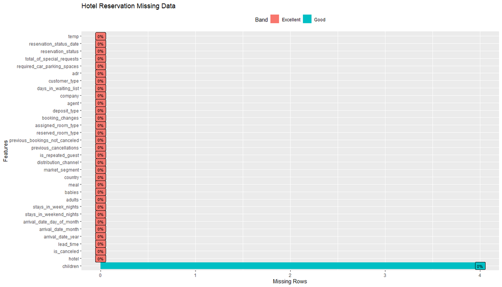

```r
  plot_missing(
    data,
    title = "Hotel Reservation Missing Data",
    group=list("Excellent" = 0.0, "Good" = .06, "Ok" = .1, "Bad" = .15),
    theme_config = list(legend.position = c("top")),
    geom_label_args = list("size" = 3, "label.padding" = unit(.3, "lines"))
  )
```

> 🔍 **OBSERVATIONS:** Based on the plot above, it looks like the only variable that contains missing values is the “children” column. Children is of type INT and is discrete. Therefore the proper imputation technique is the mean of the distribution (we will round the value to the closest integer). Note that this plot above, only shows missing values that appearin the data set as NA. For other missing values such as NULL, a more qualtitative analysis needs to be done.

```r
  # Check for any missing values (NAs), and
  # find unique indexes of column with missing values
  nas_cols_idx = unique(which(is.na(data), arr.ind=TRUE)[,2])

  # The proper imputation technique depends on the column type
  # Let's get the column name and data type
  cat("Column '",names(data[nas_cols_idx]), "' contains missing values. The data type is '", typeof(data[,nas_cols_idx]), "'.", sep = "")
```

```
Column 'children' contains missing values. The data type is 'integer'.
```

```r
  # The proper imputation technique for type INTGER is the MEAN.
  mean_children = mean(data$children, na.rm = TRUE)

  # Now we can fill in the missing values
  data$children[is.na(data$children)] <- round(mean_children)
  data$children = as.integer(data$children)
```

## 3.5 Categorical Variable Analysis

Based on the frequency distributions in the section above, we observe that some factor variables have 100+ options: very high cardinality. This is problematic from a machine learning perspective as One-Hot encoding those factor variables into dummy variables would explode the size of our data set, exponentially increasing the interpretation difficulty, taking up size, and increasing computational time. Also, the resulting model is highly like to be over-fitted, and not applicable to other realities.

Our plan is to group low-occurrence levels into a new option: “OTHER”. This will help us drastically reduce the size of categorical variables. We can then proceed with encoding the results.

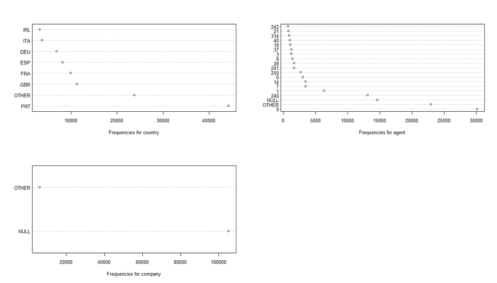

```r
  # For convenience we'll plot the factors that we are going to resize here:
  #hist(data[, which(names(data) %in% c("country","agent","company"))])

  data <- group_category(data, "country", 0.2, update = TRUE, category_name = "OTHER")
  data <- group_category(data, "agent", 0.2, update = TRUE, category_name = "OTHER")
  data <- group_category(data, "company", 0.05, update = TRUE, category_name = "OTHER")

  hist(data[, which(names(data) %in% c("country","agent","company"))])
```

```r
  data <- data %>%
    mutate(country = as.factor(country)) %>%
    mutate(agent = as.factor(agent))
```

> 🔍 **OBSERVATIONS:** We have successfully reduced the amount of levels for each of our high-cardinality categorical variables.

## 3.6 Multicollinearity

Another good thing to do next is to use a visualization of a correlation matrix plot to get a better idea of how our features relate pairwise to one another. This is an especially great tool for understating and avoid multicollinearity in regression models. We will use an educated guess as to which variables may be linearly correlated. If we find a highly correlated pattern, we can safely discard one of those variables.

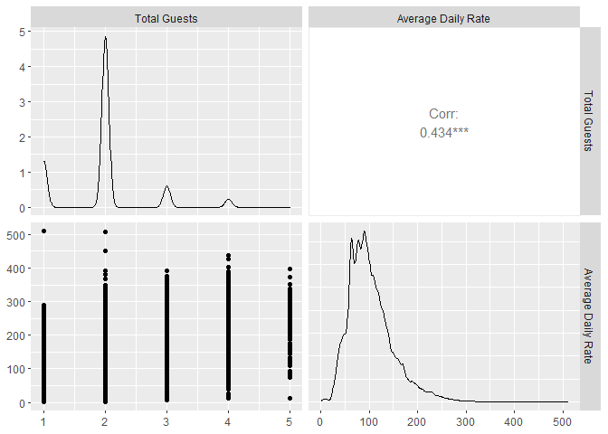

```r
  tot_guest = data$adults + data$children + data$babies
  assumption = data.frame(cbind(tot_guest,data$adr))
  colnames(assumption) <- c("Total Guests", "Average Daily Rate")
  ggpairs(assumption)
```

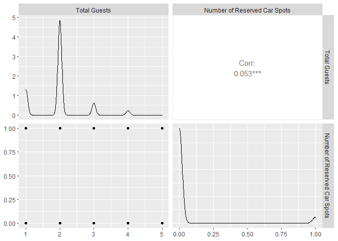

```r
  assumption = data.frame(cbind(tot_guest,data$required_car_parking_spaces))
  colnames(assumption) <- c("Total Guests", "Number of Reserved Car Spots")
  ggpairs(assumption)
```

Unintuitively total number of guests and reserved park spots is a combination of variables that is very weakly correlated.

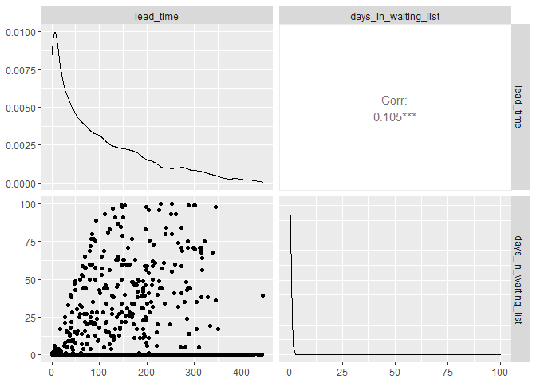

```r
  ggpairs(data[, which(names(data) %in% c("lead_time","days_in_waiting_list") )])
```

Now let’s take a look at possible linear relationship between categorical variables.

```r
  combinations <- c(
    "meal - is_repeat_gues",
    "meal - reserved_room_type",
    "meal - assigned_room_type",
    "meal - deposit_type",
    "meal - company",
    "meal - hotel",
    "meal - is_canceled",
    "market_segment - agent")
  results <- c(
    cramerV(data$meal,data$is_repeated_guest),
    cramerV(data$meal,data$reserved_room_type),
    cramerV(data$meal,data$assigned_room_type),
    cramerV(data$meal,data$deposit_type),
    cramerV(data$meal,data$company),
    cramerV(data$market_segment,data$agent),
    cramerV(data$meal,data$hotel),
    cramerV(data$meal,data$is_canceled))

  correlation <- as.data.frame(cbind(combinations, results))
  head(correlation, 8)
```

[output not shown]

> ✨ **CONCLUSION:** This concludes the data pre-processing phase. We have significantly formatted the data to make it suitable for further analysis.

## 3.7 First Study - Resort Hotel

The Resort Hotel is one of the two Hotel types we were able to gather data from. Our study attempt at describing reservation cancellation rates, via descriptive and predictive analytics. In particular, since the outcome of our response variable can assume only two states “Canceled: 1” or “Not Canceled: 0”, we will heavily leverage logistic regression. At the end of the procedure we will repeat the analysis on the secondary Hotel type, as we are interested into researching whether the same variables/predictors may affect the outcome differently depending on the hotel the reservation is made for.

### 3.7.1 Variable Selection

For variable selection, we going to take the following steps to manually eliminate some predictors.

### 3.7.2 Qualitative Analysis

Before we throw our variables into our model, it could be beneficial to understand whether ceertain predictors are even relevant for the purpose of our study:

- *reservation_status_date* can be inferred by can be inferred from the arrival date and the lead time

Let’s take a look at the other variables a bit more in detail:

```r
  # Drop reservation_status_date
  data <- data %>%
    dplyr::select(-reservation_status_date) %>%

    # By analyzing the distribution of the company column we can find that the NULL value occurs > 94% of the total distribution.
    # Since the company is almost totally devoid of values we have decided to drop it.
    dplyr::select(-company) %>%

    # update some columns as factors
    mutate(arrival_date_month = as.factor(arrival_date_month)) %>%
    mutate(arrival_date_year = as.factor(arrival_date_year)) %>%
    mutate(required_car_parking_spaces = as.factor(required_car_parking_spaces)) %>%
    mutate(previous_cancellations = as.factor(previous_cancellations))

  # Observe the reservation status column compared to is_cancelled
  describe(data$reservation_status)
```

```
data$reservation_status
       n  missing distinct
  111061        0        3

Value       Canceled Check-Out   No-Show
Frequency      40594     69357      1110
Proportion     0.366     0.624     0.010
```

```r
  describe(data$is_canceled)
```

```
data$is_canceled
       n  missing distinct
  111061        0        2

Value          0     1
Frequency  69357 41704
Proportion 0.624 0.376
```

```r
  # Observe the market segment column compared to distribution channel
  describe(data$market_segment)
```

```
data$market_segment
       n  missing distinct
  111061        0        8

lowest : Aviation      Complementary Corporate     Direct        Groups
highest: Direct        Groups        Offline TA/TO Online TA     Undefined

Value           Aviation Complementary     Corporate        Direct
Frequency            218            60          4822         11709
Proportion         0.002         0.001         0.043         0.105

Value             Groups Offline TA/TO     Online TA     Undefined
Frequency          18109         22852         53289             2
Proportion         0.163         0.206         0.480         0.000
```

```r
  describe(data$distribution_channel)
```

```
data$distribution_channel
       n  missing distinct
  111061        0        5

lowest : Corporate Direct    GDS       TA/TO     Undefined
highest: Corporate Direct    GDS       TA/TO     Undefined

Value      Corporate    Direct       GDS     TA/TO Undefined
Frequency       6010     13129       188     91729         5
Proportion     0.054     0.118     0.002     0.826     0.000
```

```r
  # We will proceed by removing those predictors
  data <- data %>%
    dplyr::select(c(-reservation_status,distribution_channel,arrival_date_year, arrival_date_day_of_month, previous_bookings_not_canceled))
```

### 3.7.3 Variable Combination / Semplification

It turns out that some variable can be combined in a larger custom variable that is going to simply the study and the interpretation of the model.

- *children* and *babies* variables will be combined into a new variable: *total_children*
- *stays_in_week_nights* and *stays_in_weekend_nights* will be combined into a new variable: *total_nights_stayed* _ *assigned_room_type* and *reserved_room_type* will be combined into a new variable: *mismatched_room* indicating whether the room had been changed or not compared to the reserved room type.

```r
  data <- data %>%
    mutate(total_children = children + babies) %>%
    dplyr::select(-c(babies, children)) %>%

    mutate(total_nights_stayed = stays_in_week_nights + stays_in_weekend_nights) %>%
    dplyr::select(-c(stays_in_week_nights, stays_in_weekend_nights)) %>%

    mutate(mismatched_room = as.factor(if_else(as.character(reserved_room_type)  ==  as.character(assigned_room_type),0,1))) %>%
    dplyr::select(-c(assigned_room_type,reserved_room_type)) %>%

    mutate(previous_cancellations = as.factor(data$previous_cancellations))
```

### 3.7.4 Level Reduction

Building on top of level-reduction steps taken in the categorical variable analysis phase, here we will further reduce levels where it makes sense. To do this we will do a quantitative analysis of frequency for each for of the categorical variables.

```r
  # Agent Column
  describe(data$agent)
```

```
data$agent
       n  missing distinct
  111061        0       19

lowest : 1     14    19    21    240  , highest: 7     8     9     NULL  OTHER

Value          1    14    19    21   240   241   242   250    28     3   314
Frequency   6308  3428  1046   762 13063  1645   729  2707  1630  1243   894
Proportion 0.057 0.031 0.009 0.007 0.118 0.015 0.007 0.024 0.015 0.011 0.008

Value         37    40     6     7     8     9  NULL OTHER
Frequency   1226   989  3013  3436  1447 30064 14549 22882
Proportion 0.011 0.009 0.027 0.031 0.013 0.271 0.131 0.206
```

```r
  # Agent #9 accounts for 27% of the distribution
  # Agent NULL (no agent) accounts for 13% of the distribution
  # Agent #240 accounts for 12% of the distribution
  # We will group the rest
  data <- data %>%
    mutate(agent = case_when(
                        agent == 9 ~ '9',
                        agent == 'NULL' ~ 'NULL',
                        agent == 240 ~ '240',
                        TRUE ~ 'Other')) %>%

    # Group total special request into 0 or 1 (indicating one or more)
    mutate(has_special_request = as.factor(ifelse(total_of_special_requests == 0,0,1))) %>%
    dplyr::select(-total_of_special_requests) %>%

    # Group number of booking_changes into 0 or 1 (indicating one or more)
    mutate(has_booking_change = as.factor(ifelse(booking_changes == 0,0,1))) %>%
    dplyr::select(-booking_changes) %>%

    # Group number total_children into 0 or 1 (indicating one or more)
    mutate(has_children = as.factor(ifelse(total_children == 0,0,1))) %>%
    dplyr::select(-total_children) %>%

    # Group SC/Undefined meal packages under one level: NM (No Meal)
    mutate(meal = case_when(
                        meal == 'BB' ~ 'BB',
                        meal == 'FB' ~ 'FB',
                        meal == 'HB' ~ 'HB',
                        meal == 'SC' ~ 'NM',
                        TRUE ~ 'NM'))

  # Set Portugal PRT as base level for country variable
   data$country <- relevel(data$country,ref='PRT')

  # Finally let's display our slimmed down data set
  #str(data)
```

### 3.7.5 Variable Selection through Step-Wise Regression

Now that we have explored variable selection from a qualitative point of view, it’s time to deploy some statistical machine learning algorithms to help us further identify strong vs weak predictors. For this step we will use *Step-wise Regression*

```r
  # Split data into Resort vs. City hotels data sub sets
  data_resortHotel <- data[which(data$hotel == 'Resort Hotel'),]
  data_cityHotel <- data[which(data$hotel == 'City Hotel'),]

  # Remove the 'hotel' variable as this field is now implicit in the subste
  data_resortHotel <- data_resortHotel %>% dplyr::select(-hotel)
  data_cityHotel <- data_cityHotel %>% dplyr::select(-hotel)

  # Split These into training and test subsets (80% and 20%)
  resortHotel_idx <- createDataPartition(data_resortHotel$is_canceled, p=0.8, list=FALSE)
  cityHotel_idx <- createDataPartition(data_cityHotel$is_canceled, p=0.8, list=FALSE)

  # Ensure reproducibility of outcome
  set.seed(123)

  data_train__resort <- data_resortHotel[resortHotel_idx,]
  data_test__resort <- data_resortHotel[-resortHotel_idx,]

  data_train__city <- data_cityHotel[cityHotel_idx,]
  data_test__city <- data_cityHotel[-cityHotel_idx,]
```

We will start with a forward step-wise regression algorithm on the Resort Hotel subset.

```r
  # Starting point Model, containing no predictors
  modZero <- glm(is_canceled ~ 1, data = data_train__resort, family = "binomial")

  # Final Model, containing all predictors
  full_model_resort <- glm(is_canceled ~
          lead_time + arrival_date_month + adults + country + market_segment + is_repeated_guest + previous_cancellations +
          deposit_type + days_in_waiting_list + customer_type + adr + required_car_parking_spaces + temp + total_nights_stayed +
          mismatched_room + agent + has_special_request + has_booking_change + has_children + meal,
            data = data_train__resort, family = "binomial")

  step_resort <- stepAIC(modZero, direction = "forward", scope = list(lower = modZero, upper = full_model_resort), k = 2, trace = F)
  #summary(step_resort)
```

> 🔍 **OBSERVATIONS:** Based on the previous procedure, it looks like the variables *previous cancellation*, *required_car_parking_spaces*, *meal* do not contribute with improving the AIC score. Thus, we won’t consider them when building our logist regression model.

```r
  final_model_resort_1 <- glm(is_canceled ~
          deposit_type + agent + country + lead_time + has_special_request + has_booking_change + adr + is_repeated_guest +
          market_segment + customer_type + total_nights_stayed + arrival_date_month + days_in_waiting_list + temp + adults +
          has_children,
            family = "binomial",  data = data_train__resort)
  #summary(final_model_resort_1)
```

```r
  # Here we will adjust the variables according to what we've observed from the StepAIC results

  # Adjustments - Train subset Resort Hotel
  data_train__resort <- data_train__resort %>%
    mutate(deposit_type_grp = ifelse(deposit_type == 'Non Refund', 'NonRefund', "Other")) %>%
    mutate(deposit_type_grp = relevel(factor(deposit_type_grp), ref="Other")) %>%
    mutate(agent_grp = case_when(
                                agent == 'NULL' ~ 'Other',
                                agent == 'Other' ~ 'Other',
                                TRUE ~ '9_240')) %>%
    mutate(customer_type_grp = case_when(
                                customer_type == 'Transient' ~ 'Transient',
                                TRUE ~ 'Other'
                              )) %>%
    mutate(arrival_month_grp = case_when(
                                arrival_date_month == 2 ~ 2,
                                arrival_date_month == 6 ~ 6,
                                arrival_date_month == 7 ~ 7,
                                arrival_date_month == 8 ~ 8,
                                arrival_date_month == 9 ~ 9,
                                arrival_date_month == 10 ~ 10,
                                TRUE ~ 0)) %>%
    mutate(arrival_month_grp = as.factor(arrival_month_grp))


  data_test__resort <- data_test__resort %>%
    mutate(deposit_type_grp = ifelse(deposit_type == 'Non Refund', 'NonRefund', "Other")) %>%
    mutate(deposit_type_grp = relevel(factor(deposit_type_grp), ref="Other")) %>%
    mutate(agent_grp = case_when(
                                agent == 'NULL' ~ 'Other',
                                agent == 'Other' ~ 'Other',
                                TRUE ~ '9_240')) %>%
    mutate(customer_type_grp = case_when(
                                customer_type=='Transient' ~ 'Transient',
                                TRUE ~ 'Other'
                              )) %>%
    mutate(arrival_month_grp = case_when(
                                arrival_date_month == 2 ~ 2,
                                arrival_date_month == 6 ~ 6,
                                arrival_date_month == 7 ~ 7,
                                arrival_date_month == 8 ~ 8,
                                arrival_date_month == 9 ~ 9,
                                arrival_date_month == 10 ~ 10,
                                TRUE~0)) %>%
    mutate(arrival_month_grp = as.factor(arrival_month_grp))
```

For what concerns the country variable, we will construct the 95% confidence interval chart to see if the estimated means are truly different from each other.

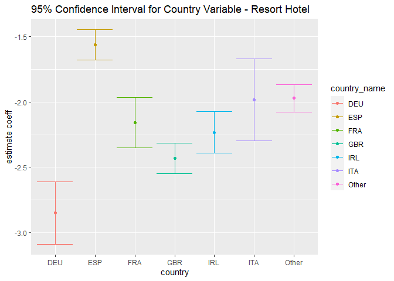

```r
  # We will use the 95% Confidence Interval for country variable, to reduce levels.

  country <- data.frame(
    country_name = c("DEU","ESP","FRA","GBR","IRL","ITA","Other"),
    country_est = c(
      final_model_resort_1$coefficients["countryDEU"],
      final_model_resort_1$coefficients["countryESP"],
      final_model_resort_1$coefficients["countryFRA"],
      final_model_resort_1$coefficients["countryGBR"],
      final_model_resort_1$coefficients["countryIRL"],
      final_model_resort_1$coefficients["countryITA"],
      final_model_resort_1$coefficients["countryOTHER"]),
    lower_bound = c(
      final_model_resort_1$coefficients["countryDEU"]-1.96*coef(summary(final_model_resort_1))[, "Std. Error"]["countryDEU"],
      final_model_resort_1$coefficients["countryESP"]-1.96*coef(summary(final_model_resort_1))[, "Std. Error"]["countryESP"],
      final_model_resort_1$coefficients["countryFRA"]-1.96*coef(summary(final_model_resort_1))[, "Std. Error"]["countryFRA"],
      final_model_resort_1$coefficients["countryGBR"]-1.96*coef(summary(final_model_resort_1))[, "Std. Error"]["countryGBR"],
      final_model_resort_1$coefficients["countryIRL"]-1.96*coef(summary(final_model_resort_1))[, "Std. Error"]["countryIRL"],
      final_model_resort_1$coefficients["countryITA"]-1.96*coef(summary(final_model_resort_1))[, "Std. Error"]["countryITA"],
      final_model_resort_1$coefficients["countryOTHER"]-1.96*coef(summary(final_model_resort_1))[, "Std. Error"]["countryOTHER"]),
    upper_bound = c(
      final_model_resort_1$coefficients["countryDEU"]+1.96*coef(summary(final_model_resort_1))[, "Std. Error"]["countryDEU"],
      final_model_resort_1$coefficients["countryESP"]+1.96*coef(summary(final_model_resort_1))[, "Std. Error"]["countryESP"],
      final_model_resort_1$coefficients["countryFRA"]+1.96*coef(summary(final_model_resort_1))[, "Std. Error"]["countryFRA"],
      final_model_resort_1$coefficients["countryGBR"]+1.96*coef(summary(final_model_resort_1))[, "Std. Error"]["countryGBR"],
      final_model_resort_1$coefficients["countryIRL"]+1.96*coef(summary(final_model_resort_1))[, "Std. Error"]["countryIRL"],
      final_model_resort_1$coefficients["countryITA"]+1.96*coef(summary(final_model_resort_1))[, "Std. Error"]["countryITA"],
      final_model_resort_1$coefficients["countryOTHER"]+1.96*coef(summary(final_model_resort_1))[, "Std. Error"]["countryOTHER"])
    )


    ggplot(country, aes(country_name,country_est, color=country_name, fill=country_name)) +
    geom_point() +
    geom_errorbar( aes(ymin=lower_bound,ymax=upper_bound) )+labs(title="95% Confidence Interval for Country Variable - Resort Hotel",x="country",y="estimate coeff")
```

> 🔍 **OBSERVATIONS:**
> - Based on the plot above, it looks like DEU, ESP do not overlap with others, so their coefficients are statistically different from each other
> - FRA and IRL overlap with each other, so their coefficients are not statistically different from each other.
> - GRB will be considered by itself.
> - ITA and Other overlapped, so their coefficients are not statistically different from each other.

Now will proceed with grouping country levels:

```r
data_train__resort <- data_train__resort %>%
  mutate(country = case_when(
                      country == 'DEU' ~ 'DEU',
                      country == 'ESP' ~ 'ESP',
                      country == 'FRA' ~ 'FRA_IRL',
                      country == 'IRL' ~ 'FRA_IRL',
                      country == 'GBR' ~ 'GBR',
                      country == 'PRT' ~ 'PRT',
                      TRUE ~ 'ITA_OTH')) %>%
  mutate(country = relevel(factor(country), ref="PRT"))

data_test__resort <- data_test__resort %>%
  mutate(country = case_when(
                      country == 'DEU' ~ 'DEU',
                      country == 'ESP' ~ 'ESP',
                      country == 'FRA' ~ 'FRA_IRL',
                      country == 'IRL' ~ 'FRA_IRL',
                      country == 'GBR' ~ 'GBR',
                      country == 'PRT' ~ 'PRT',
                      TRUE ~ 'ITA_OTH')) %>%
  mutate(cuntry = relevel(factor(country), ref="PRT"))
```